# 060_Global Variable Analysis

by Craig W. Slinkman

7/27/2019

## Univariate analysis for $miles$ walked

The following is an analysis miles walked variable.

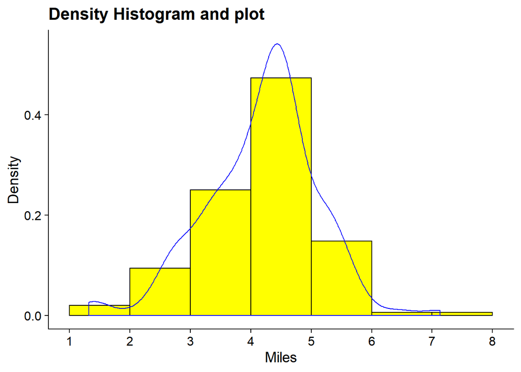

### Normal quantile-quantile plot of miles

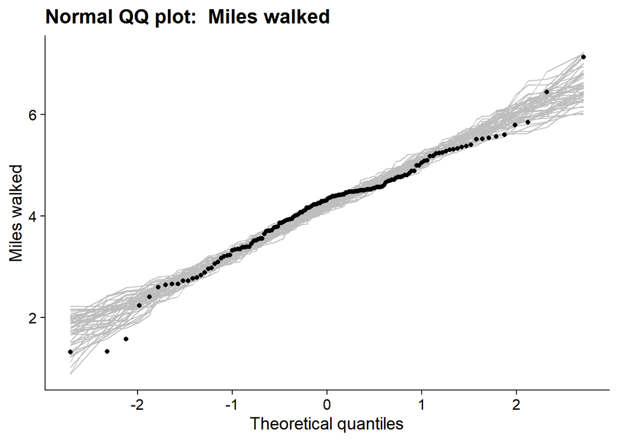

#### Bootstrap estimate of the population mean

| Statistics | Estimates | Bias | Standard Error | Sample Size | Replications |
| --- | --- | --- | --- | --- | --- |
| Mean: | 4.1785 | 0.0000 | 0.0762 | 148 | 1,025 |
| Standard Deviation: | 0.9263 | 0.0000 | 0.0644 | 148 | 1,025 |

### Bootstrap diagnostic plots

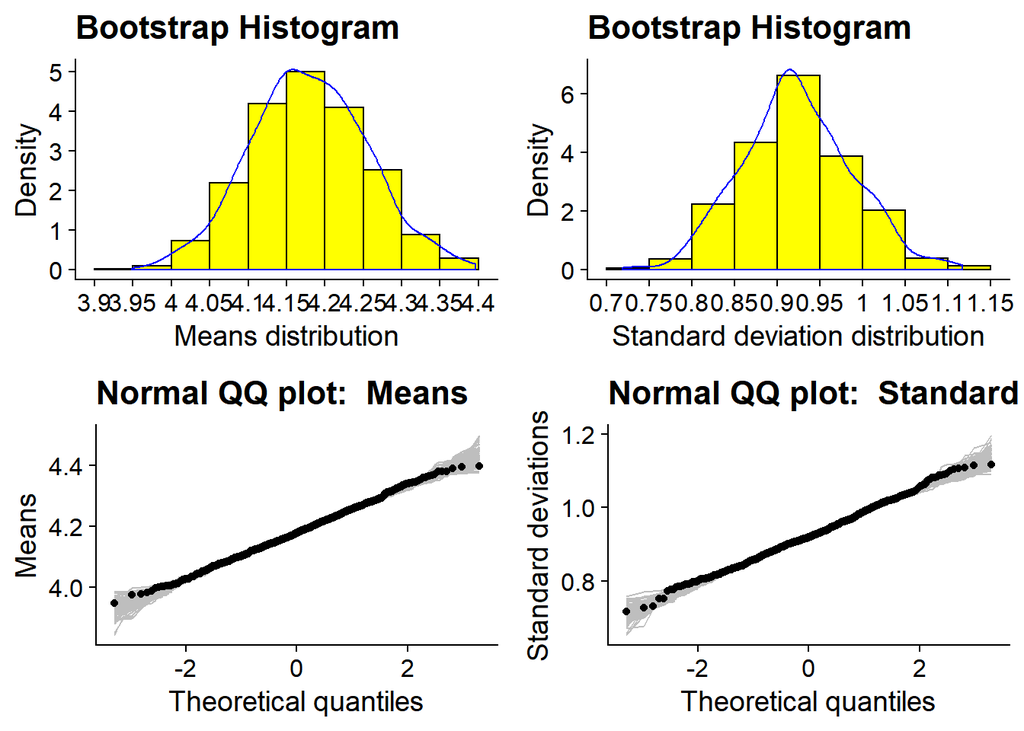

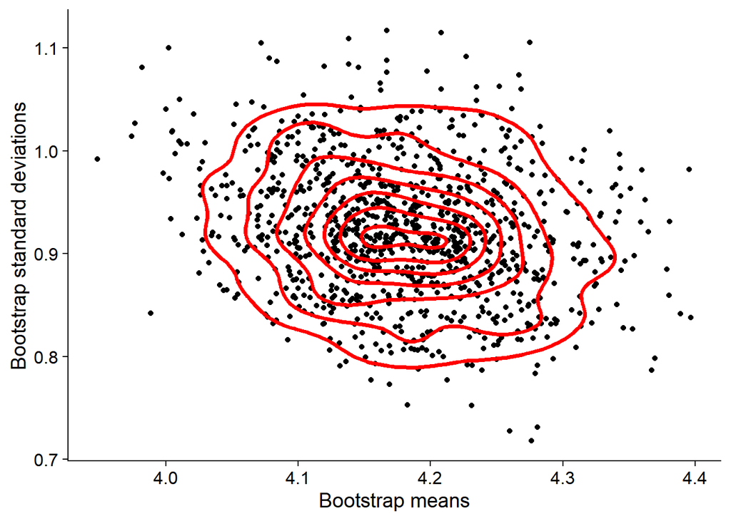

### Correlation of bootstrap estimates

If the bootstraped means and standard errors are normally idstributed then they be uncorrelated. We compute the correlation matrix to investicate if the correlation between the means and standard deviations are ubcorreleated.

```
##
##  Pearson's product-moment correlation
##
## data:  bsample$ybar and bsample$std
## t = -7.2031, df = 1023, p-value = 1.14e-12
## alternative hypothesis: true correlation is not equal to 0
## 95 percent confidence interval:
##  -0.2772072 -0.1606332
## sample estimates:
##        cor
## -0.2197043
```

#### Bootstrap 95% confidence intervals for the mean and standard deviation of miles walked

```
## BOOTSTRAP CONFIDENCE INTERVAL CALCULATIONS
## Based on 1025 bootstrap replicates
##
## CALL :
## boot.ci(boot.out = boot.out, type = interval_types, index = 1)
##
## Intervals :
## Level      Normal              Basic              Percentile
## 95%   ( 4.028,  4.327 )   ( 4.019,  4.329 )   ( 4.028,  4.338 )
## Calculations and Intervals on Original Scale
```

```
## BOOTSTRAP CONFIDENCE INTERVAL CALCULATIONS
## Based on 1025 bootstrap replicates
##
## CALL :
## boot.ci(boot.out = boot.out, type = interval_types, index = 2)
##
## Intervals :
## Level      Normal              Basic              Percentile
## 95%   ( 0.8036,  1.0559 )   ( 0.8016,  1.0482 )   ( 0.8043,  1.0509 )
## Calculations and Intervals on Original Scale
```

### Predictions

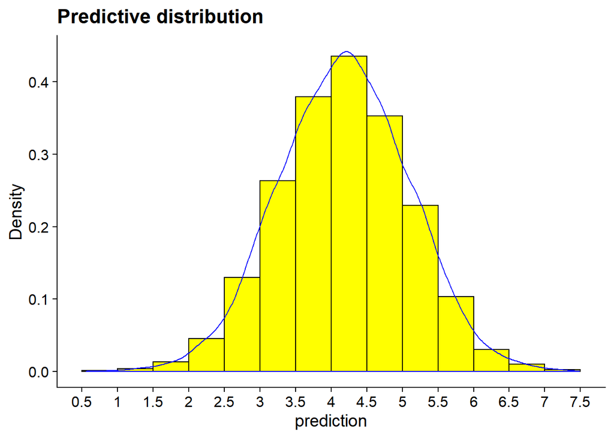

#### Assessing the bias of the prediction distribution

Here we assess the degree of bias do to the bootstrap and simulation.

| Mean Prediction | Sample Mean | Bias | Percent bias | Prediction Standard deviation |
| --- | --- | --- | --- | --- |
| 4.181929 | 4.178514 | 0.003415291 | 0.1 | 0.9144943 |

The value of the bias is small when compared to the mean and standard deviation so we can ignore it.

#### Diagnostic plots of prediction distribution

We draw a density histogram with a density plot and a normal quantile-quantile plot to assess the normality of the prediction distribution. If the distribution appear to be normally distributed then we can use the normal distribution to assess the the prediction intervals.

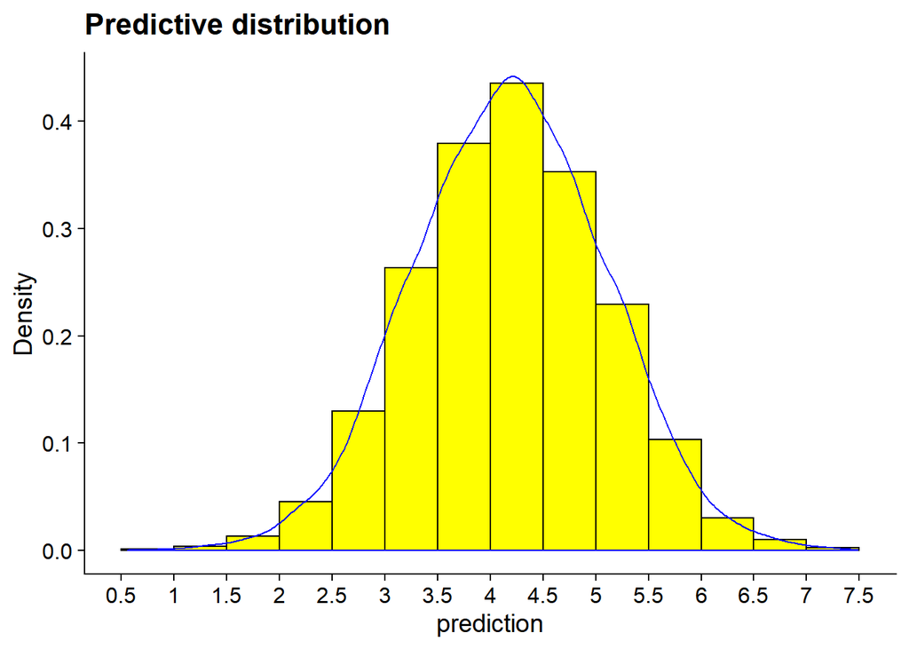

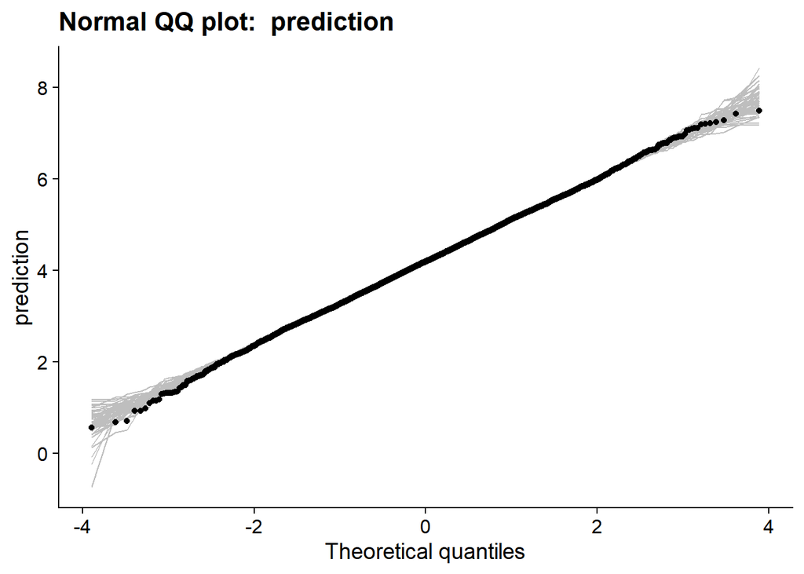

#### Compute prediction intervals

G. E. P Box once recommended that one should give more one confidence interval to give the user an idea of the degree of risk to the user of the confidence intervals. We do that here computing the 50%, 0.75, 90%, 95%, and 99% confidence intervals.

### Predictions and prediction intervals

| Probability | Lower | Forecast | Upper |
| --- | --- | --- | --- |
| 50% | 3.56 | 4.18 | 4.80 |
| 75% | 3.13 | 4.18 | 5.23 |
| 90% | 2.68 | 4.18 | 5.68 |
| 95% | 2.39 | 4.18 | 5.97 |
| 98% | 2.05 | 4.18 | 6.31 |
| 99% | 1.82 | 4.18 | 6.54 |

This may seem like a wide interval. This is due to some short walks I took six months ago which inflated the standard deviation of the error. The length of different routes alks varies widely and this also increases the standard deviation.